# Housing Capacity and Equity Around Diridon Station

Where San José’s biggest transit investment can add homes — and for whom

Author

Kasey Zapatka

Published

July 2, 2026

**NoteExecutive Summary**

**The problem:** Zoning within a mile of Diridon Station permits **~120,000 homes**, but the City’s plans call for only ~34,300 and just ~12,800 exist today — while 38% of Downtown’s zoned land sits underbuilt, much of it surface parking, in a neighborhood that is **69% renters** earning below the citywide median.

**The recommendation:** Plan bigger — move growth targets toward the capacity the zoning already grants — and build the soft sites first: **~20,600–42,500 homes** on parking lots and vacant land, addable without displacement, paired from the start with inclusionary requirements and tenant protections.

## The question

Diridon is the San Francisco Bay Area’s flagship transit-oriented development site: the future convergence of BART’s Silicon Valley extension, California High-Speed Rail, Caltrain, and Google’s “Downtown West.” It is exactly the kind of station area where regions hope to concentrate new housing. Two questions decide whether that hope is realistic:

1. **Capacity** — does the zoning actually permit enough housing near the station, and how much of it is on land that could realistically redevelop?
2. **Equity** — who lives there now, and would adding homes put them at risk?

## Approach

We work at the parcel level within a 1-mile area of the Diridon Station (~5,279 parcels, ~1,420 acres)[^1]. For each parcel that permits housing we compute theoretical maximum capacity as *lot acreage × maximum dwelling units per acre*, using real maximum densities from San José’s zoning code[^2] and the Diridon Station Area Plan for the Downtown core. We then narrow to soft-site capacity by keeping only **soft sites**[^3]: high-capacity parcels that are currently vacant or barely built. This is gross zoned capacity *on underbuilt land*, not capacity net of existing units. Finally we overlay ACS 2019–2023 demographics and the City’s Equity Index to characterize who lives in the station area today. Full detail and caveats are in Methods & Sources.

## Finding 1 — High capacity is located downtown within 1 mile of Diridon Station

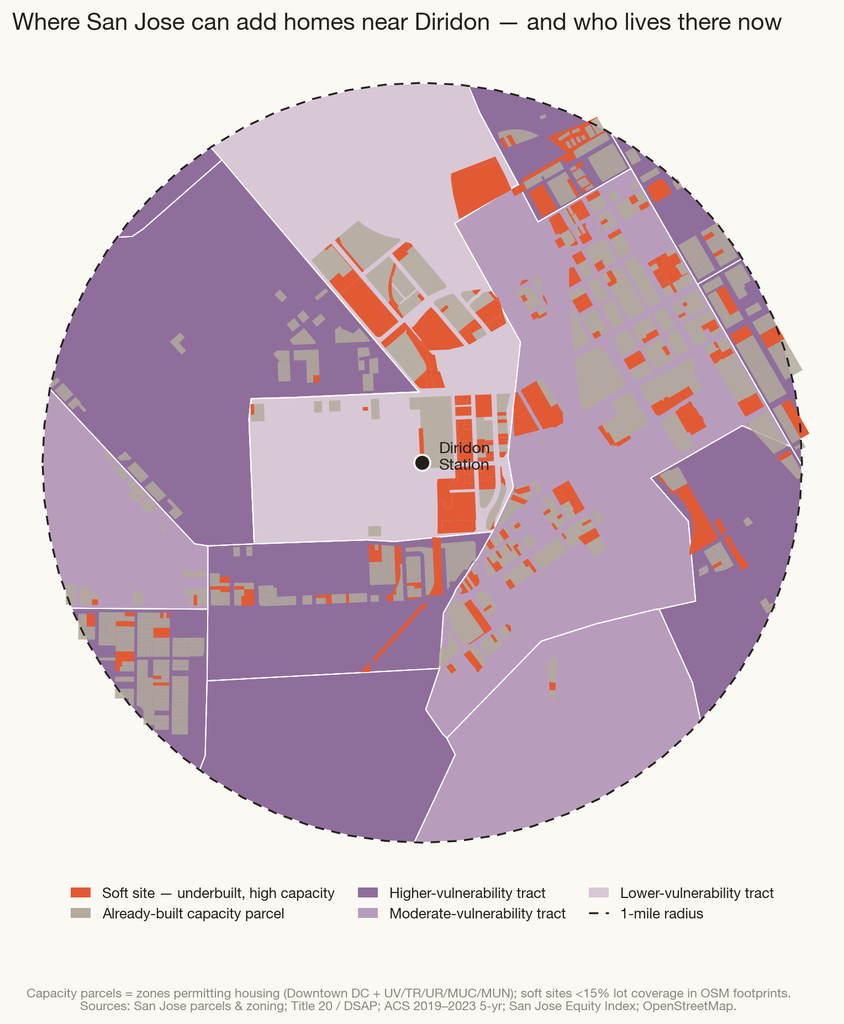

Figure 1: **The story in one map.** Coral parcels are *soft sites* — underbuilt, high-capacity lots clustered tightly around the station and through the Downtown core. They sit atop neighborhoods shaded by displacement vulnerability.

Housing capacity near Diridon comes from two kinds of zoning (Figure 3).

1. The first is familiar: the six **mixed-use / urban-village districts**, which cover about 100 acres and permit roughly 14,700 homes at mid-rise densities.
2. The second is the **Downtown (DC) core** itself — Diridon sits at downtown’s western edge, but 300 acres of it fall inside the 1-mile ring — which, under a conservative 350 du/ac cap, permits roughly 105,000 homes.

Together: 14,700 + 105,000 ≈ **120,000 homes of gross zoned capacity**, nearly nine-tenths of it downtown. However, current estimates suggest the 1-mile area around the station falls well short of its maximum zoning potential.

There are two issues here: (1) the city doesn’t plan to build as much as it could, and (2) parking and undeveloped land.

### What the City plans vs. what could be done

The first gap is between what the zoning *allows* and what the City actually *plans*. Summing the City’s own growth-area programs across the ring — the Downtown growth area, the Diridon Station Area Plan, and six urban villages, each counted only for the share of its land inside the 1-mile circle — the City plans roughly **34,300 new homes** here[^4]. That is ambitious by regional standards — nearly a tripling of today’s ~12,800-home stock — yet less than a third of the ~120,000-home envelope (Figure 2). The envelope is a ceiling, not a target, but the distance between them is the policy space.

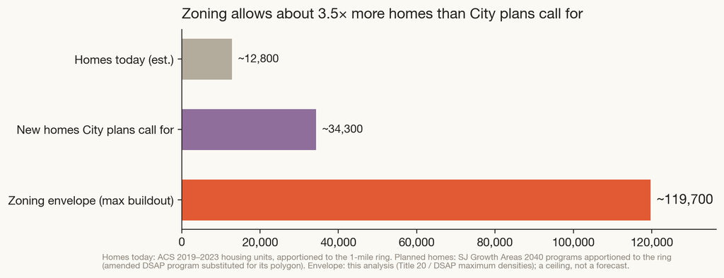

### Parking and undeveloped land – one opportunity

The second issue is what occupies the zoned land today. Much of it is already built out, but a striking share is not: roughly **38% of Downtown’s zoned land is underbuilt today, much of it surface parking**. Counting only these soft sites — parcels that are vacant, parking lots, or barely built — the zoning still supports up to **~42,500 homes** on land that holds almost no housing today, a defensible range of **~20,600–42,500** once uncertain parcels are set aside.[^5]

This is why soft sites matter: they are where housing can be added **soonest and with the least conflict**. No residents to displace, no viable buildings to demolish, often single-ownership lots that skip years of parcel assembly — and every parking lot that becomes homes puts residents, transit riders, and street life where the region’s largest transit investment needs them. Cities that hit their TOD targets do it largely on land like this, which is why housing-element site inventories are built around it. San José’s downtown parking problem is, in effect, its largest near-transit housing opportunity.

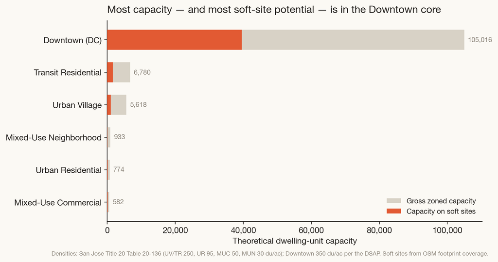

Figure 3: Gross zoned capacity (grey) versus zoned capacity on underbuilt soft sites (coral), by zone. The Downtown core dominates both.

## Finding 2 — Middle and working class stand to benefit

Compared with San José as a whole, the 1-mile area is overwhelmingly home to renters who are more likely to be rent burdened, have higher poverty rates and more dependent on public transit. They also have lower median incomes than the city overall — residents most exposed to rent pressure if redevelopment is not managed.

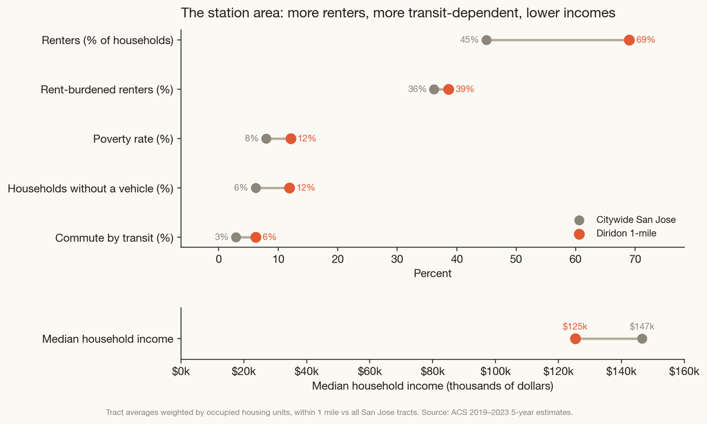

Figure 4: Station-area tracts versus citywide San José, ACS 2019–2023. The station area is markedly more renter-occupied and transit-dependent. (Whole tracts intersecting the 1-mile ring, weighted by occupied housing units.)

The overlap should shape implementation: **~22% of soft-site capacity sits in higher-vulnerability tracts** — including the area’s genuinely low-income neighborhoods — with ~32% in moderate- and ~46% in lower-vulnerability, largely commercial downtown land. New supply here serves exactly the renters most exposed to being priced out while it is built.

## Recommendation

**Two moves: plan bigger, and bank the soft sites first.**

**1. Close the ambition gap.** The City’s own growth-area programs call for ~34,300 homes in the ring — less than a third of the ~120,000 its zoning already permits. Diridon is the rare station area where ambition requires no rezoning fight: the entitlement ceiling is already there. The city should update the plan to meaningfully move towards the zoning potential, concentrating the increase in the Downtown core where capacity, transit, and underbuilt land already coincide.

**2. Treat the soft sites as the short-term win.** Some **~20,600–42,500 homes** of capacity sit on parking lots and vacant land — buildable without displacing residents or demolishing viable buildings, and enough to more than double, and possibly quadruple, today’s ~12,800-home stock while longer-horizon sites work through entitlement. Sequence them first, and pair them from the start with inclusionary requirements and tenant protections for the few occupied parcels — because the surrounding population is renter-majority, transit-reliant, and below the citywide median income, supply alone risks raising rents faster than it adds affordability. My own research supports exactly this pairing: tenant protections work best coupled with supply-expanding inclusionary zoning,[^6] and parcel-level analysis shows displacement pressure can be anticipated — and mitigated — before it arrives.[^7]

## Caveats

This is **theoretical zoned capacity**, not a production forecast — it measures what the code permits, not what the market will build. Soft sites are an *open- data proxy* (footprint coverage), so the Downtown figure is a ceiling: some zero-coverage parcels are the station, rail right-of-way, or open space rather than developable land. Vulnerability flags identify *exposure*, not predicted displacement, and ACS estimates carry margins of error. See Methods & Sources for thresholds, sensitivity, and data lineage.

**Data sources.**

- [City of San José Open Data](https://data.sanjoseca.gov/organization/maps-data) — parcels, zoning districts, Equity Index tracts, Growth Areas 2040
- [San José Municipal Code Title 20](https://library.municode.com/ca/san_jose/codes/code_of_ordinances?nodeId=TIT20ZO) (Zoning), Table 20-136
- [Diridon Station Area Plan](https://www.sanjoseca.gov/your-government/departments-offices/planning-building-code-enforcement/planning-division/citywide-planning/area-specific-plans/diridon-station-area-plan) (amended 2021)
- [American Community Survey](https://www.census.gov/programs-surveys/acs) 2019–2023 5-year estimates
- [OpenStreetMap](https://www.openstreetmap.org) building footprints (© OpenStreetMap contributors)

Analysis and figures: Kasey Zapatka, 2026. Full methodology: Methods & Sources.

## Footnotes

[^1]: Distances are computed in California State Plane Zone 3 (US survey feet), a locally accurate projection — not Web Mercator, which inflates distances by ~26% at this latitude and would silently shrink the study area to ~0.8 mile. See Methods & Sources.
[^2]: Title 20 of the San José Municipal Code is the city’s zoning ordinance. Its Table 20-136 (Ch. 20.55, Urban Village and Mixed Use districts) sets the development standards — including the maximum dwelling units per acre — for each of the mixed-use zones used here (UV, TR, UR, MUC, MUN, UVC).
[^3]: “Soft site” is planning shorthand — common in housing-element site inventories — for a parcel whose current use is well below what its zoning allows, making redevelopment plausible: vacant land, a surface parking lot, or a marginal one-story building. Here a parcel qualifies as a soft site when buildings cover less than 15% of the lot; Methods & Sources reports how the results change under other thresholds (5–25%) and the approach’s limits. We identify them for this project using OpenStreetMap building-footprint coverage (< 15% of the lot built).
[^4]: San José Growth Areas 2040 (General Plan) polygons, planned housing apportioned by each area’s share of land inside the ring; the DSAP polygon overlaps the Downtown growth area, so its footprint is subtracted from Downtown’s before apportioning. For the DSAP itself we use the amended (2021) program of ~12,900 homes with a 25% affordability goal — also stated in the City’s Transit-Oriented Communities letter to MTC — rather than the pre-amendment figure (2,710) still carried in the Growth Areas layer. Detail: `output/tables/growth_areas_in_ring.csv`.
[^5]: Three qualifiers, detailed in Methods & Sources and the FAQ: (1) this is gross capacity on redevelopable land, not net of existing units; (2) about half (~21,900 units) sits on parcels with no detected building at all — some genuinely vacant, some likely rail, station, or civic land — and excluding all of them leaves the ~20,600 floor; and (3) we do not net out the active development pipeline: the City’s *Major Private Development Footprints* layer (~130 projects) records locations and status but not unit counts, so subtracting entitled projects (several large Downtown soft sites likely overlap Google’s Downtown West) would require hand-collected counts — the natural next refinement.
[^6]: Zapatka, K., & de Castro Galvao, B. (2022). Affordable Regulation: New York City Rent Stabilization as Housing Affordability Policy. *City & Community*. doi:10.1177/15356841221123762
[^7]: Zapatka, K., & Beck, B. (2021). Does demand lead supply? Gentrifiers and developers in the sequence of gentrification, New York City 2009–2016. *Urban Studies*. doi:10.1177/0042098020940596